# 6776566_assignment_EDA

Dataset details: The dataset is downloaded from Kaggel. It is Star Classifier, i.e., it is a compliation of various properties of stars in the universe. It has columns that show following details of a star: Temperature,Luminosity,Radius,Absolute magnitude,Star type,Star color and Spectral Class.

Operations Performed: In this assignment, I have tried to explore this data set and have tried to find various relations between properties, for example: whether star of some “type” are brighter(have more luminosity) than stars of other “type”. I also tried to find out the biggest star and the brightest star according to the dataset. By performing these operations on the dataset, I learned about using various R functionalities and also a lot about properties of a star. One of the most interesting fact that I came to know from this is that even though the size of star is related to its brightness, that doesnot mean that the brightest star will be hottest.

```r
library(tidyverse)
```

#importing dataset

```r
star_dataset <- read.csv("~/Programming/R/Data Analysis and Visualisation/Assignments/6776566Exploratory_Data_Analysis/data/star_dataset.csv")
```

#getting a glimpse of the dataset

```r
head(star_dataset)
```

```
##   Temperature..K. Luminosity.L.Lo. Radius.R.Ro. Absolute.magnitude.Mv.
## 1            3068         0.002400       0.1700                  16.12
## 2            3042         0.000500       0.1542                  16.60
## 3            2600         0.000300       0.1020                  18.70
## 4            2800         0.000200       0.1600                  16.65
## 5            1939         0.000138       0.1030                  20.06
## 6            2840         0.000650       0.1100                  16.98
##   Star.type Star.color Spectral.Class
## 1         0        Red              M
## 2         0        Red              M
## 3         0        Red              M
## 4         0        Red              M
## 5         0        Red              M
## 6         0        Red              M
```

#getting summary of the dataset

```r
summary(star_dataset)
```

```
##  Temperature..K. Luminosity.L.Lo.    Radius.R.Ro.
##  Min.   : 1939   Min.   :     0.0   Min.   :   0.0084
##  1st Qu.: 3344   1st Qu.:     0.0   1st Qu.:   0.1028
##  Median : 5776   Median :     0.1   Median :   0.7625
##  Mean   :10497   Mean   :107188.4   Mean   : 237.1578
##  3rd Qu.:15056   3rd Qu.:198050.0   3rd Qu.:  42.7500
##  Max.   :40000   Max.   :849420.0   Max.   :1948.5000
##
##  Absolute.magnitude.Mv.   Star.type          Star.color  Spectral.Class
##  Min.   :-11.920        Min.   :0.0   Red         :112   A: 19
##  1st Qu.: -6.232        1st Qu.:1.0   Blue        : 55   B: 46
##  Median :  8.313        Median :2.5   Blue-white  : 26   F: 17
##  Mean   :  4.382        Mean   :2.5   Blue White  : 10   G:  1
##  3rd Qu.: 13.697        3rd Qu.:4.0   yellow-white:  8   K:  6
##  Max.   : 20.060        Max.   :5.0   White       :  7   M:111
##                                       (Other)     : 22   O: 40
```

#we do not want to use scientific notations in R

```r
options(scipen=999)
```

```r
star_dataset %>% filter(Star.color == "Blue" & Radius.R.Ro. > 100)
```

```
##   Temperature..K. Luminosity.L.Lo. Radius.R.Ro. Absolute.magnitude.Mv.
## 1           26000           316000       1679.0                  -9.10
## 2           18000           200000       1045.0                  -8.30
## 3           38234           272830       1356.0                  -9.29
## 4           32489           648430       1948.5                 -10.84
## 5           38940           374830       1356.0                  -9.93
## 6           30839           834042       1194.0                 -10.63
## 7           37882           294903       1783.0                  -7.80
##   Star.type Star.color Spectral.Class
## 1         5       Blue              B
## 2         5       Blue              O
## 3         5       Blue              O
## 4         5       Blue              O
## 5         5       Blue              O
## 6         5       Blue              O
## 7         5       Blue              O
```

#applying arrange function to the dataset. This gives us a Blue star with lowest temprature.

```r
star_dataset %>% filter(Star.color == "Blue" & Radius.R.Ro. > 100) %>% arrange(Temperature..K.)
```

```
##   Temperature..K. Luminosity.L.Lo. Radius.R.Ro. Absolute.magnitude.Mv.
## 1           18000           200000       1045.0                  -8.30
## 2           26000           316000       1679.0                  -9.10
## 3           30839           834042       1194.0                 -10.63
## 4           32489           648430       1948.5                 -10.84
## 5           37882           294903       1783.0                  -7.80
## 6           38234           272830       1356.0                  -9.29
## 7           38940           374830       1356.0                  -9.93
##   Star.type Star.color Spectral.Class
## 1         5       Blue              O
## 2         5       Blue              B
## 3         5       Blue              O
## 4         5       Blue              O
## 5         5       Blue              O
## 6         5       Blue              O
## 7         5       Blue              O
```

#applying select function to the dataset

```r
star_dataset %>% filter(Star.color == "Blue" & Radius.R.Ro. > 100) %>% arrange(Temperature..K.) %>%
select(Luminosity.L.Lo., Spectral.Class)
```

```
##   Luminosity.L.Lo. Spectral.Class
## 1           200000              O
## 2           316000              B
## 3           834042              O
## 4           648430              O
## 5           294903              O
## 6           272830              O
## 7           374830              O
```

#Finding the biggest star

```r
max(star_dataset$Radius.R.Ro.)
```

```
## [1] 1948.5
```

```r
star_dataset %>% filter(Radius.R.Ro. == 1948.5) %>% select(Temperature..K., Luminosity.L.Lo., Radius.R.Ro., Absolute.magnitude.Mv., Star.type, Star.color, Spectral.Class)
```

```
##   Temperature..K. Luminosity.L.Lo. Radius.R.Ro. Absolute.magnitude.Mv.
## 1           32489           648430       1948.5                 -10.84
##   Star.type Star.color Spectral.Class
## 1         5       Blue              O
```

#Finding the brightest star

```r
max(star_dataset$Luminosity.L.Lo.)
```

```
## [1] 849420
```

```r
star_dataset %>% filter(Luminosity.L.Lo. == 849420) %>% select(Temperature..K., Luminosity.L.Lo., Radius.R.Ro., Absolute.magnitude.Mv., Star.type, Star.color, Spectral.Class)
```

```
##   Temperature..K. Luminosity.L.Lo. Radius.R.Ro. Absolute.magnitude.Mv.
## 1           27739           849420         1252                  -7.59
##   Star.type Star.color Spectral.Class
## 1         5 Blue-white              B
```

#Creating plots

#This plot shows that stars of type 4 and 5 are brighter than others.

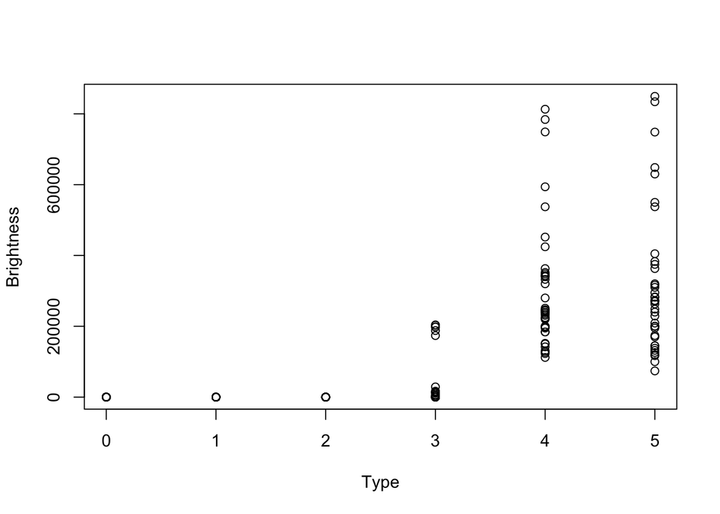

```r
plot(x = star_dataset$Star.type, y = star_dataset$Luminosity.L.Lo., xlab = "Type", ylab = "Brightness")
```

```r
TypeBright <- ggplot(star_dataset, aes(x = Star.type, y = Luminosity.L.Lo.)) + geom_point() +
labs(x = "Type", y = "Brightness", title = "Plot showing how the Type of a star affects its luminosity") + geom_density_2d() + theme_minimal()
```

#This plot shows that the type 5 stars are biggest in size. It also indicates the Spectral Class of stars.

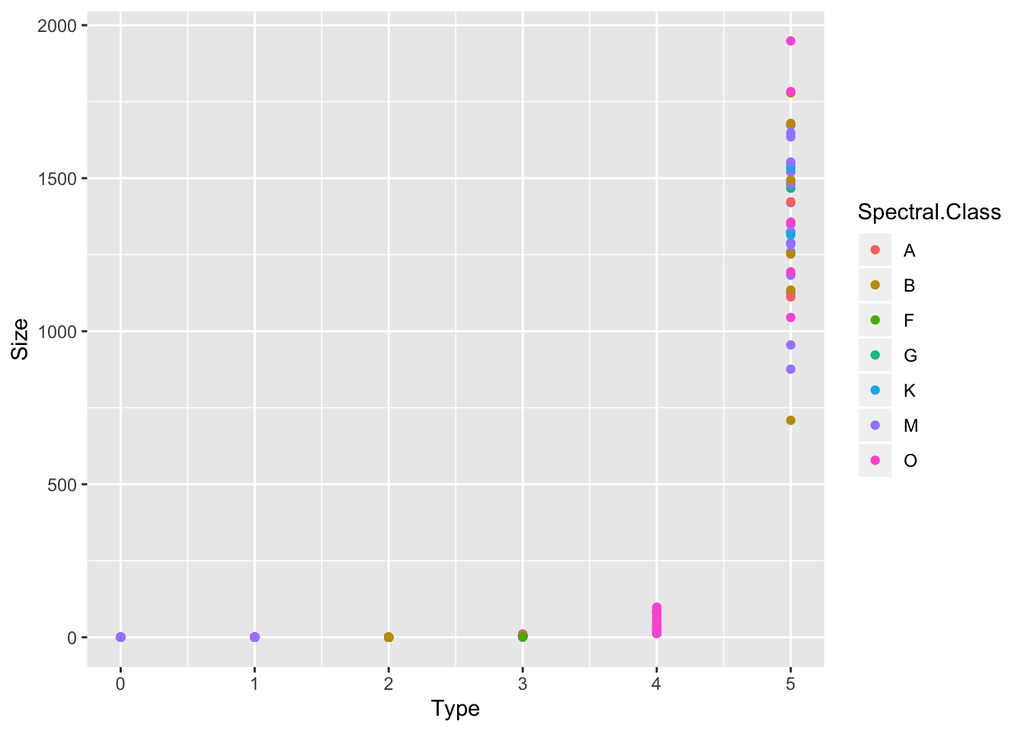

```r
TypeSize <- ggplot(star_dataset, aes(x = Star.type, y = Radius.R.Ro.)) + geom_point(aes(colour = Spectral.Class)) +
labs(x = "Type", y = "Size")
TypeSize
```

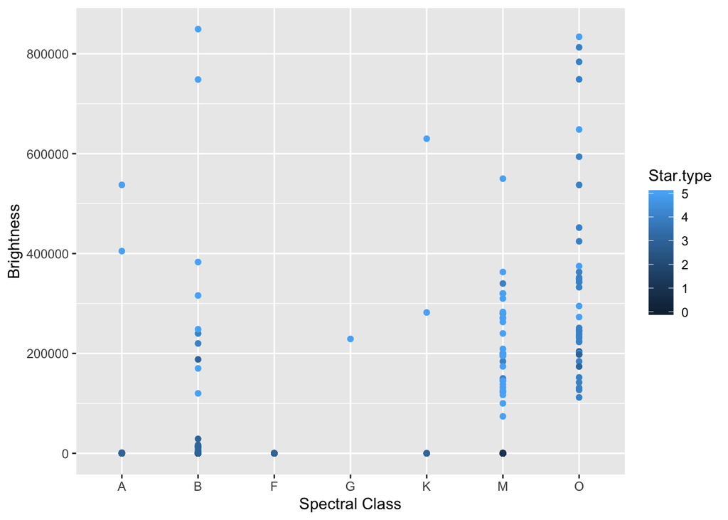

```r
ClassBright <- ggplot(star_dataset, aes(x = Spectral.Class, y = Luminosity.L.Lo.)) +
  geom_point(aes(colour = Star.type)) +
  labs(x = "Spectral Class", y = "Brightness")
ClassBright
```

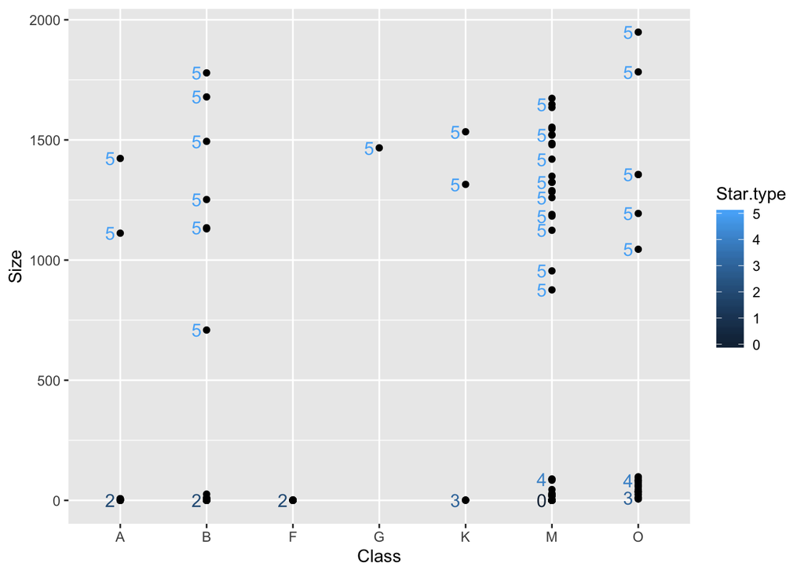

```r
ClassSize <- ggplot(star_dataset, aes(x = Spectral.Class, y = Radius.R.Ro.)) + geom_point() +
labs(x = "Class", y = "Size") + geom_text(aes(label = Star.type, colour = Star.type), check_overlap = TRUE, size = 4, hjust = 1.5, yjust = 1.5)
ClassSize
```

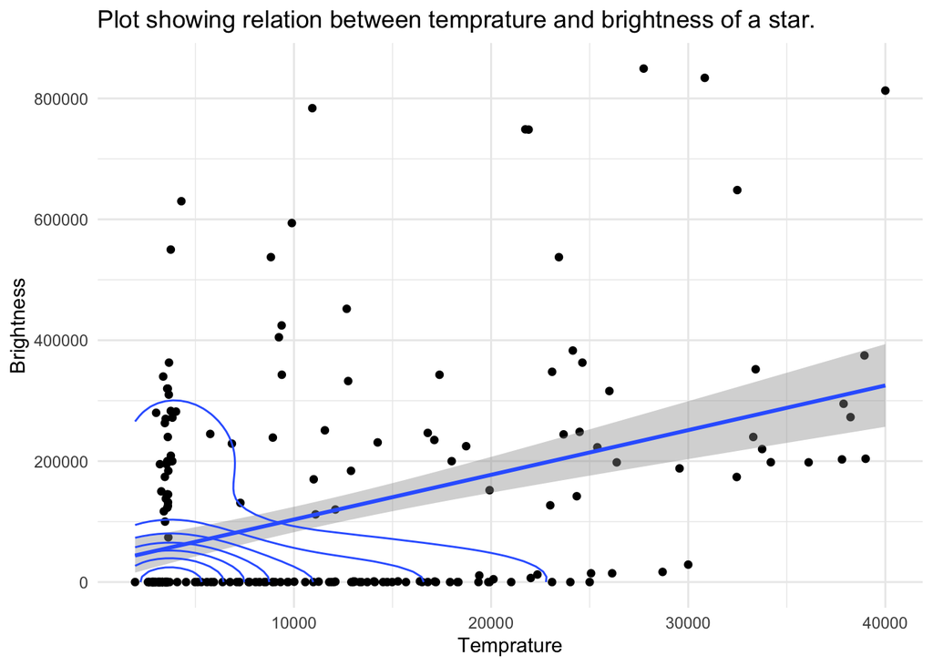

```r
TempBright <- ggplot(star_dataset, aes(x = Temperature..K., y = Luminosity.L.Lo.)) + geom_point() + geom_smooth(method = "lm") + labs(x = "Temprature", y = "Brightness", title = "Plot showing relation between temprature and brightness of a star.") + geom_density_2d() + theme_minimal()

TempBright
```

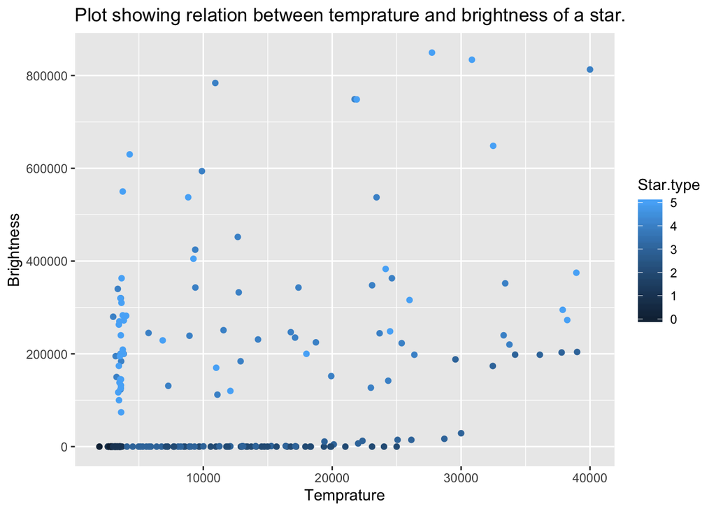

```r
star_dataset %>%
  ggplot(aes(x = Temperature..K., y = Luminosity.L.Lo.)) + geom_point(aes(colour = Star.type)) +
  labs(x = "Temprature", y = "Brightness", title = "Plot showing relation between temprature and brightness of a star.")
```